# Some points on the DEB-IPM

Viktor Thunell

2020-12-03

### Survival function

1. Egg survival

The eggs survival parameter (egg_surv) represents survival from laid egg to age 1 (censused in spring) since we apply a post-reproductive census. The parameter thus includes survival of eggs, larvae and young of the year. I have used this parameter to scale the long-term population growth rate $\lambda$ to a value slightly above 1 at the reference temperature (similar to Vindenes et al. 2014). Such survival is of course highly variable and uncertain but worth a rough estimate for comparison, i.e if this estimate is far from what we need to use as a parameter value for the model to obtain a reasonable $\lambda$.

When dividing our `eqq_surv` parameter with 5 (1e-5) $\lambda$ is 1.0466899 for $\kappa = 0.8$ at reference temperature (283 K). Given that there are many assumptions in this model and quite a few uncertainties, its rewarding to see that the main free parameter is off by less than an order of magnitude.

2. Temperature & size dependent survival

A minimum requirement of the model is to have survival depend on temperature and size as these are the predictors of all rates in the DEB and vital rates in the IPM. As I haven’t dealt with models of mortality/survival before, I had some reading up to do which resulted in an allometric mortality rate relationship on the form ($(aM^{b})$) with a temperature function of the type used for Intake and Maintenance rate.

Lorenzon (1996) estimated parameters for a weight dependent allometric power function of mortality in fish in natural environments (river, lake and marine) and culture systems (pond, cage and tank). His parameter estimates for natural systems were $a=3$ (for 1 gram unit weight) and $b=-0.288$ for yearly mortality. The estimate of $b$ is similar to theoretical estimates of -0.25 of Peterson & Wroblewski (1984) and -0.24 of Brown et al. (2004). Brown et al. (2004) also provide an estimate of the slope of 0.47 for the temperature sensitivity (activation energy) of mortality.
$$-3*m^{-.288} * e^{0.47*(T-T0)/(k*T*T0)}$$

Survival is calculated as $Survival = e^{-Mortality}$.

```r
plot(x, DEBsurvfun(x, GR_pars), type="l", col="red",ylim=c(0,1))
```

[output not shown]

*Alternative options specific for Windermere pike:*

- Vindenes et al. 2014 uses a Monte Carlo re-sampling procedure on length based on mark-recapture data. Using weight calculated from length I could estimate a weight dependent function following this procedure. While this is tempting as it would be very instructive for me and the best alternative for assessing a natural pike population (if we want to test the model on Windermere data), I think it would be time consuming and maybe come at the cost of model generality.
- The simple alternative would be to eye-estimate weight dependent survival from the curve of length dependent survival in Vindenes et al. 2014. I would like to not use eye-estimates and this function has has quite a few parameters which would make estimation tedious work.

The survival estimated in Vindenes et al. 2014 has a sigmoid shape which differs from the current negative exponential form of mortality.

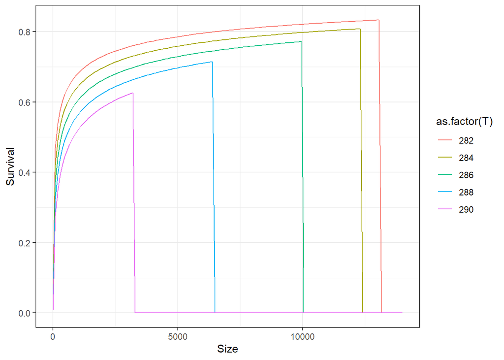

3. Starvation survival

The DEBsurvfunction are conditional for starvation survival. When Maintenance rate ($M(m,T)$) exceeds allocable energy ($\alpha*Y*I(m,T)$) survival is 0. This conditon is however, that if this years size is larger than next years mean ($x > \sigma_y$), i.e. if an individual shrinks enough for this cndition to be met, starvation occurs. The level of starvation survival (currently 0) is optional.

### Offspring size function

1. Mean temperature dependent offspring size

While the variance I estimate of offspring size from Lake Windermere pike data using a length to weight relationship for juveiles (`lotw_J()`) `sd(ltow_J((GData[GData$Age==1,]$Length)))^2`, is temperature independent we want the mean to estimated by the DEB to include the trade-off implied by $\kappa$.

The mean offspring (Age 1) size in the data independent of temperature is 76 gram. Between 9.5 and 10.5 degrees Celcius (our T0 is 283 K or 10 degrees Celsius) the mean size is 23 cm or 50 gram (Using the L-W relationship for juveniles, `lotw_J`). `lotw_J(mean(GData2[GData2$Age==1 & GData2$Temp < 10.5 & GData2$Temp > 9.5,]$Length))`.

We want to model the temperature dependence of offspring size so that, at the mean temperature of 10 degrees, it is comparable to data from Lake Windermere. If we use the DEB growth function for one growing season on egg size (i.e offmeanTemp = ratefun(o_e,GR_pars)[184,2]) we obtain offspring an order of magnitude of that size. This is in part due to that we use mass exponents < 1 on mass < 1 making the ratio intake/mass >> 1 for the curent parametr values. The intake becomes large for the egg size (0.0035 g) because the parameters for the size and temperature scaling that are suitable for larger fish but not to estimate growth from egg to age 1 (which is also small compared to subsequent years). To obtain a smaller offspring I make to two assumptions, a) that a laid egg does not actively feed and grow in mass throughout the growing season and b) that the intake rate (through the feeding level $Y$) are much lower than what our intake function generates for small sizes ($x<1$). I then fit parameters to obtain a good offspring estimate).

1. In the time to hatching from laid eggs and in the yolk sac period, the offspring does not gain weight. This period can be more than a month long (33.6 days at 16.3 degrees, Houde & Zastrow 1993). Development of pike eggs is highly temperature dependent, extending from days to a months (Swift 1965, Morrow 1980). Also, growth of fry is slow and the period from the start of active feeding to reaching weight > 1 gram can be another month at our reference temperature (T0) due to low availability of larger and nutritious prey (Bry et al. 1991). When setting the length of the growth period during the first year of life I avoid making a larger number of assumptions and uncertain calculations and choose to simply divide season length($s_l$) by 2.
2. By multiplying intake rate for individuals < 1 gram with 0.4, we bring down the intake rate enough to achieve an offspring size of 55 gram at 283 K.

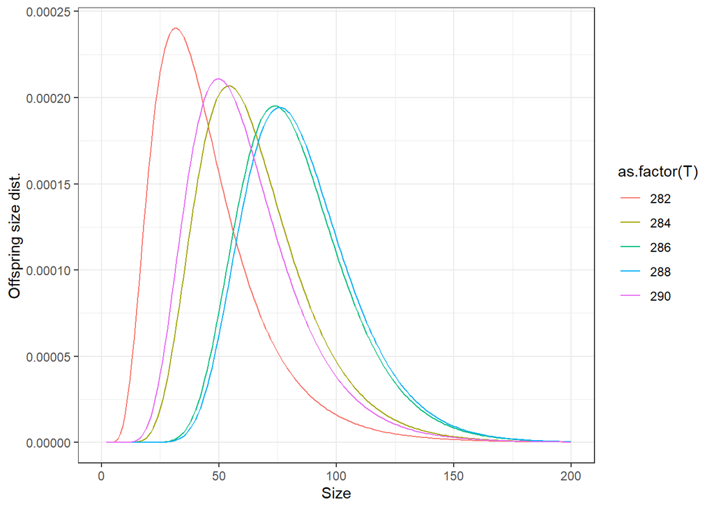

### Fecundity

No maintenance for reproductive investment is included yet. P rocessing energy reserve to build gonads shuold be costly, and some DEBs take that into account. But this will come with trade offs concerning the relative size of such costs compared to maintenance costs that we include which more work but might provide interesting questions.

The DEBrepfunction gives the fecundity of an individual in t+1 that in the start of t is m. If an individual that at the start of the season (in t) is below maturation size will start building energy reserve when maturation size is reached in that season and produce eggs in t+1. The mean egg weight in Lake Windermere data is 0.00351388 g. Devm is size at maturation and 38 cm (Vindenes et al. 2014), i.e. length to weight for juveniles `ltow_J(38)`.

Fecundity is deterministic and size and temperature dependent through the DEB. As $\kappa$ is fixed over size, the non-linear size scaling of fecundity is a product of size dependent energy availability, i.e. the DEB-over-size curve, not of $\kappa$. The DEB underestimates reproduction for large individuals:

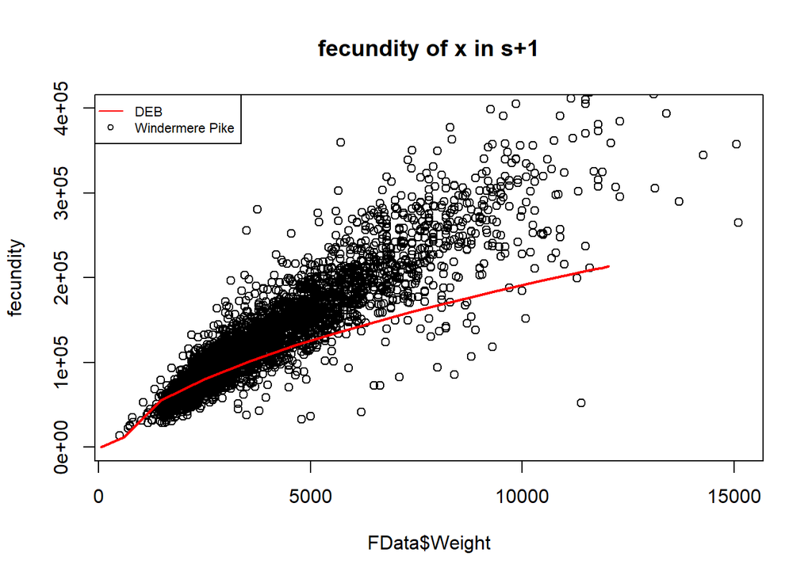

Changing the fixed kappa does not increase the energy available for larger individuals without increasing it for small. This is due to that the DEB-function, decreases the slope for both growth and reproduction for large individuals. Since we do not have e.g. a genetic component that decreases growth independent of the DEB, we can’t model energy dependent reproductive strategies for larger sizes using the DEB with a fixed Kappa. Changing the size dependence of intake relative to maintenance could work but not without affecting the growth curve, which I think is quite reasonable as it is. As I see it, if we want to mimic the reproductive strategy of the Windermere pike (and probably many other capital breeding fish species) for our model, we need a size dependent Kappa so that reproduction increases with size more than growth. With such an allometric Kappa that decreases with size (less energy to growth, more to reproduction) in combination with increasing the size scaling of intake rate we can increase the energy budget for reproduction for large individuals. Of course, the best solution is to test both scenarios and choose the most appropriate for the main, and the other for a supplementary analysis.

### Growth function

1. Choosing values of size and temperature parameters for maintenance and intake rate

Building the model to represent temperature dependent growth and fecundity, and fitting this to the Windermere data mainly boils down to choosing parameters for intake and maintenance. My procedure for choosing these parameter values has been to first set allometric scaling parameters of maintenance and intake (rho1,2 and eps1,2 in the code) to build growth funcions in the mean environment (283 Kelvin) and then temperature dependent parameter values to build temperature-size-rule type growth curves.

Estimates of maintenance rate over size and temperature exists in Armstrong et al. (1992) and Lindmark et al. (2019) re-estimated his measurements to [$gram * day^{-1}$] which suits our model. Following Lindmark et al. 2019 I re-estimated his size scaling parameters for 292 K to 283 K which is the close to mean temperature in the Lake Windermere data (Vindenes et al. 2014).

Intake is variable in the life of a fish and its scaling relationships with size and temperature (and their interaction) for pike is scarce to non-existent in the literature. Therefore I have considered the size-scaling parameters of intake (eps1,2) as free parameters and set them to adjust the growth curve to fit data (sensu Essington et al. 2001). It is important to consider that the main goal is to reproduce growth and fecundity patterns in Lake Windermere.

2. Growth variance

This is important for the functionality of the IPM. We had discussions in the meeting (september 30). So now we have describe variance as the variation in growth over size at the individual level (not among indivduals of a particular size). We use a function in which growth variance decreases exponentially over size.

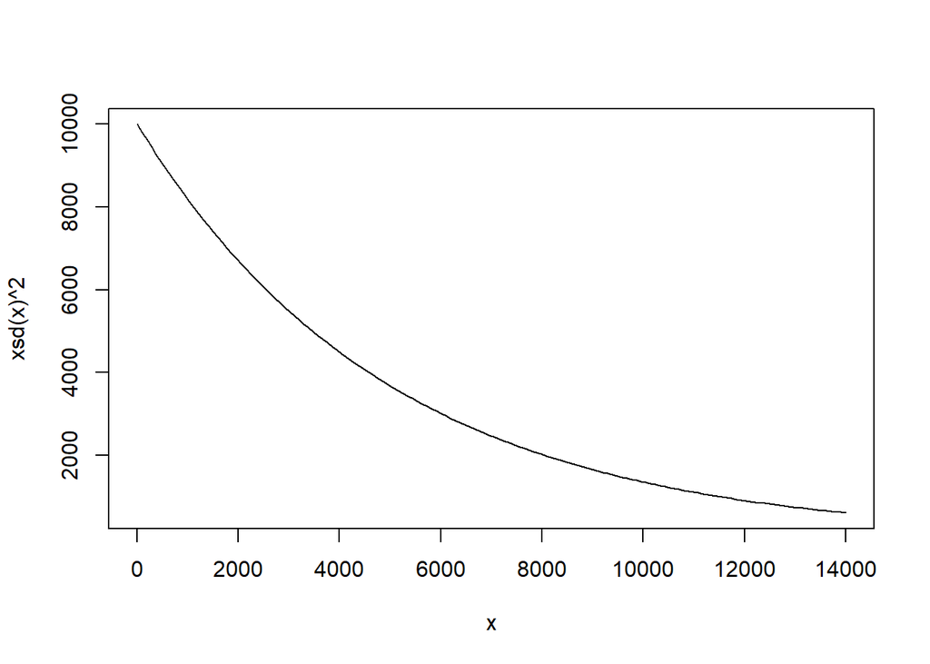

3. Starvation in the growth function

Growth in the DEB-function can be negative so that biomass is lost when maintenance costs exceeds allocable energy for growth. An individual of size x that grows in the beginning of a season could starve later in the season. During such conditions, the indidual is likely to not survive to nexxt year.

## References

Armstrong, J. D., I. G. Priede, and M. C. Lucas. 1992. The link between respiratory capacity and changing metabolic demands during growth of northern pike, Esox lucius L. Journal of Fish Biology 41:65-75.

Brown, J. H., J. F. Gillooly, A. P. A., V. M. Savage, and G. B. West. 2004. Towards a metabolic theory of ecology. Ecology 85:1771-1789.

Bry, C., M. G. Hollebecq, V. Ginot, G. Israel, and J. Manelphe. 1991. Growth patterns of pike (Esox lucius L.) larvae and juveniles in small ponds under various natural temperature regimes. Aquaculture 97:155-168.

Essington, T. E., J. F. Kitchell, and C. J. Walters. 2001. The von Bertalanffy growth function, bioenergetics, and the consumption rates of fish. Canadian Journal of Fisheries and Aquatic Sciences 58:2129-2138.

Houde, E.D. and C.E. Zastrow, 1993. Ecosystem- and taxon-specific dynamic and energetics properties of fish larvae assemblages. Bull. Mar. Sci. 53(2):290-335

Kipling, C., and W. E. Frost. 1970. A Study of the Mortality, Population Numbers, Year Class Strengths, Production and Food Consumption of Pike, Esox lucius L., in Windermere from 1944 to 1962. The Journal of Animal Ecology 39.

Lindmark, M., J. Ohlberger, M. Huss, and A. Gårdmark. 2019. Size-based ecological interactions drive food web responses to climate warming. Ecol Lett 22:778-786.

Lorenzen, K. 1996. The relationship between body weight and natural mortality in juvenile and adult fish: a comparison of natural ecosystems and aquaculture. Journal of Fish Biology 49:627-642.

Morrow, J.E., 1980. The freshwater fishes of Alaska. University of. B.C. Animal Resources Ecology Library. 248p.

Peterson, I., and J. S. Wroblewski. 1984. Mortality Rate of Fishes in the Pelagic Ecosystem. Canadian Journal of Fisheries and Aquatic Sciences 41:1117-1120.

Swift, D. R. 1965. Effect of Temperature on Mortality and Rate of Development of the Eggs of the Pike (Esox lucius L.) and the Perch (Perca fluviatilis L.). Nature 206:528-528

Vindenes, Y., E. Edeline, J. Ohlberger, O. Langangen, I. J. Winfield, N. C. Stenseth, and L. A. Vollestad. 2014. Effects of climate change on trait-based dynamics of a top predator in freshwater ecosystems. Am Nat 183:243-256.